# Quadratische Funktionen - Die drei Darstellungsformen

## Einführung

In diesem Notebook lernst du die drei verschiedenen Darstellungsformen einer quadratischen Funktion kennen:

1. **Scheitelpunktform**: $f(x)=a\cdot(x−d)^2+e$
2. **Faktorisierte Form** - auch Nullstellenform genannt: $f(x)=a\cdot(x−x1)\cdot(x−x2)$
3. **Polynomform** - auch allgemeine Form genannt: $f(x)=ax^2+bx+c$

Jede Form hat ihre eigenen Stärken und zeigt unterschiedliche Eigenschaften der Parabel!

Am Ende diesen Kapitels solltest du folgendes gelernt haben:

1. Ich kann die drei Darstellungsarten quadratischer Funktionen aufschreiben.
2. Ich kann die die Bedeutung der Parameter in jeder Darstellungsform erklären.
3. Ich kann die Eigenschaften einer Parabel aus jeder Darstellungsform ablesen.
4. Ich kann den Scheitelpunkt aus jeder Darstellungsform bestimmen.

## 1. Die Scheitelpunktform

$$f(x)=a\cdot(x−d)^2+e$$

**Aufgabe:** Verändere die Funktionsgleichung durch bewegen der Slider. Welches Muster erkennst du in der Funktionsgleichung?

```
interactive(children=(FloatSlider(value=1.0, description='a', max=3.0, min=-3.0), FloatSlider(value=0.0, descr…
```

```
<function __main__.plot_scheitelpunkt(a=1, d=0, e=0)>
```

**Aufgabe:** Was kann man aus der **Scheitelpunktform** direkt ablesen?

```
Accordion(children=(Output(),), titles=('✅ Lösung anzeigen',))
```

## 2. Die faktorisierte Form (Nullstellenform)

$$f(x) = a\cdot(x-x_1)\cdot(x-x_2)$$

### 2.1 Wiederholung des Begriffs **Nullstelle**

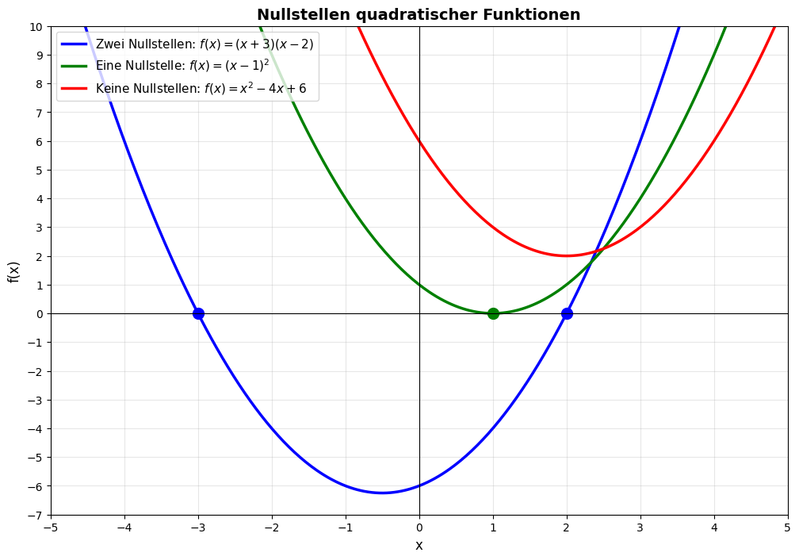

**Frage:** Was versteht man unter den Nullstellen einer Parabel?

```
Accordion(children=(Output(),), titles=('✅ Lösung anzeigen',))
```

**Frage:** Wie viele Nullstellen kann eine Parabel haben?

```
Accordion(children=(Output(),), titles=('✅ Lösung anzeigen',))
```

**Frage:** Wie berechnet man die Nullstellen einer Parabel?

```
Accordion(children=(Output(),), titles=('✅ Lösung anzeigen',))
```

### 2.2 Ablesbare Eigenschaften der Parabel

**Aufgabe:** Verändere die Funktionsgleichung durch Bewegen der Slider. Welches Muster erkennst du in der Funktionsgleichung?

```
interactive(children=(FloatSlider(value=1.0, description='a', max=3.0, min=-3.0), FloatSlider(value=-2.0, desc…
```

```
<function __main__.plot_faktorisiert(a=1, x1=-2, x2=2)>
```

**Frage:** Was kann man aus der **faktorisierten Form** (Nullstellenform) direkt ablesen?

```
Accordion(children=(Output(),), titles=('✅ Lösung anzeigen',))
```

**Frage:** Wie sieht die faktorisierte Form aus, wenn es nur **eine Nullstelle** gibt?

```
Accordion(children=(Output(outputs=({'output_type': 'display_data', 'data': {'text/plain': '<IPython.core.disp…
```

```
Accordion(children=(Output(),), titles=('✅ Lösung anzeigen',))
```

**Frage:** Wie sieht die faktorisierte Form aus, wenn es **keine Nullstellen** gibt?

```
Accordion(children=(Output(),), titles=('✅ Lösung anzeigen',))
```

#### Zusammenfassung: Eigenschaften der Parabel ausgehend von der Nullstellenform

An einer Funktionsgleichung, die in Nullstellenform gegeben ist,

$$f(x) = a \dot (x - x_{1}) \cdot (x - x_{2})$$

können wir folgendes direkt ablesen:

- **Nullstellen**: $x_1$ und $x_2$ (*oder evtl. nur eine Nullstelle*)
- **Öffnung**:
  - $a>0$ → nach oben
  - $a<0$ → nach unten
- **Streckung**:
  - $|a|>1$ → gestreckt
  - $|a|<1$ → gestaucht

### 2.3 Bestimmung des Scheitelpunkts ausgehend von der Nullstellenform

**Frage:** Wo liegt die **x-Koordinate des Scheitelpunkts** in Bezug auf die Nullstellen?

```
Accordion(children=(Output(outputs=({'output_type': 'display_data', 'data': {'text/plain': '<IPython.core.disp…
```

```
Accordion(children=(Output(),), titles=('✅ Lösung anzeigen',))
```

**Frage:** Angenommen wir kennen die x-Koordinate $d$ des Scheitelpunkts. Wie bestimmen wir dann die **y-Koordinate $e$ des Scheitelpunkts**?

```
Accordion(children=(Output(),), titles=('✅ Lösung anzeigen',))
```

#### Zusammenfassung: Bestimmung des Scheitelpunkts ausgehend von der Nullstellenform

Um den Scheitelpunkt $S(d|e)$ ausgehend von einer Funktionsgleichung in Nullstellenform zu bestimmen, gehen wir wie folgt vor:

**1. Wir bestimmen die x-Koordinate $d$ des Scheitelpunkts**

Da der Scheitelpunkt immer in der Mitte zwischen den beiden Nullstellen liegt, können wir seine x-Koordinate folgendermaßen berechnen:

$$d = \frac{x_{1} + x_{2}}{2}$$

**2. Wir bestimmen die y-Koordinate $e$ des Scheitelpunkts**

Wir setzen $d$ in die Funktionsgleichung ein und berechnen dadurch $e$.

$$e = f(d)$$

### 2.4 Übungen

**Aufgabe:**

Gegeben ist $f(x) = 2 \cdot (x - 1) \cdot (x + 3)$

Bestimme

1. Die **Nullstellen** der Parabel

2. Die **Öffnungsrichtung** der Parabel

3. Die **Streckung** der Parabel

4. Den **Scheitelpunkt** der Parabel

```
Accordion(children=(Output(),), titles=('✅ Lösung anzeigen',))
```

**Aufgabe:**

Gegeben ist $g(x) = -3(x+2)(x-4)$

Bestimme

1. Die **Nullstellen** der Parabel

2. Die **Öffnungsrichtung** der Parabel

3. Die **Streckung** der Parabel

4. Den **Scheitelpunkt** der Parabel

```
Accordion(children=(Output(),), titles=('✅ Lösung anzeigen',))
```

**Aufgabe:**

Gegeben ist $h(x)=\frac{1}{2}(x-5)(x+1)$

Bestimme

1. Die **Nullstellen** der Parabel

2. Die **Öffnungsrichtung** der Parabel

3. Die **Streckung** der Parabel

4. Den **Scheitelpunkt** der Parabel

```
Accordion(children=(Output(),), titles=('✅ Lösung anzeigen',))
```

**Aufgabe:**

Gegeben ist $k(x)=-2(x-3)^2$

Bestimme

1. Die **Nullstellen** der Parabel

2. Die **Öffnungsrichtung** der Parabel

3. Die **Streckung** der Parabel

4. Den **Scheitelpunkt** der Parabel

```
Accordion(children=(Output(),), titles=('✅ Lösung anzeigen',))
```

## 3. Die Polynomform (allgemeine Form)

$$f(x) = ax^2 + bx + c$$

### 3.1 Wiederholung des Begriffs **y-Achsenabschnitt**

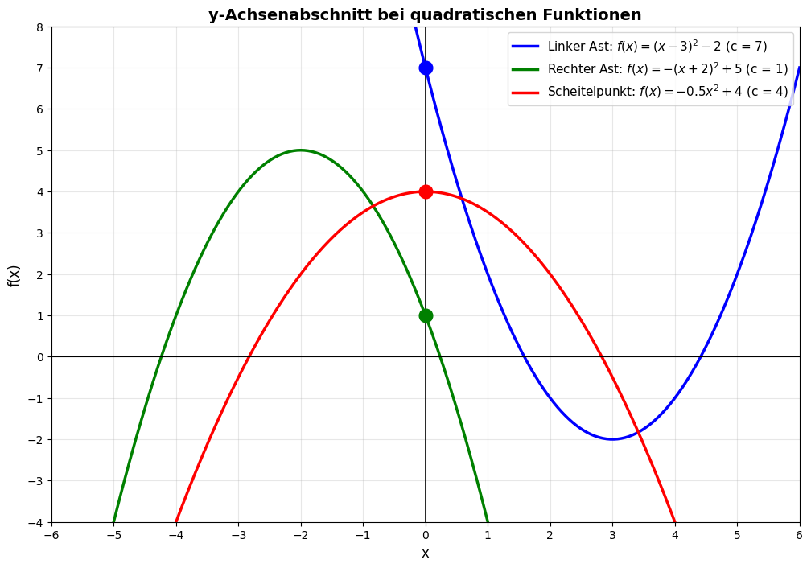

**Aufgabe:** Was versteht man unter dem *y-Achsenabschnitt* einer Parabel?

```
Accordion(children=(Output(),), titles=('💡 Lösung anzeigen',))
```

**Aufgabe:** Wie berechnet man den *y-Achsenabschnitt* einer Parabel?

```
Accordion(children=(Output(),), titles=('💡 Lösung anzeigen',))
```

```
interactive(children=(FloatSlider(value=1.0, description='a', max=3.0, min=-3.0), FloatSlider(value=0.0, descr…
```

```
<function __main__.plot_polynom(a=1, b=0, c=0)>
```

## 4. Vergleich: Welche Form für welchen Zweck?

[output not shown]